# Project 1: Wrangling, Exploration, Visualization

SDS322E

## Data Wrangling, Exploration, Visualization

### Sonali Patel svp539

#### Introduction

My first dataset, “SAT” discusses SAT scores and educational expenditures across states distribution among states.It is a data frame with 50 observations (1 per state) for the following variables: state, expend, ratio, salary, frac, verbal, math, and sat. My second dataset, “US arrests” has the statistics in arrests per 100,000 residents of the 50 states for assault, murder, and rape. It contains 50 observations for the four variables: murder, assault, urbanpop, and rape. I am interested in exploring the relationship between the variable “expend” from the SAT dataset, which is the expenditure per pupil in average daily attendance in public elementary and secondary schools, in thousands of US dollars and the variable “Murder”, which is numeric murder arrests per 100,000, in the US arrests dataset. I am mostly interested in if there is a relationship between the educational expenditures and murder arrests in the 1990s.I would expect higher educational expenditures to result in lower murder arrests, and vice versa.

```r
library(tidyverse)
data2 <- SAT <- read.csv(file = "SAT.csv", stringsAsFactors = FALSE)
data1 <- USArrests <- read.csv(file = "USArrests.csv", stringsAsFactors = FALSE)
data(SAT)

USArrests
```

```
##              X Murder Assault UrbanPop Rape
## 1      Alabama   13.2     236       58 21.2
## 2       Alaska   10.0     263       48 44.5
## 3      Arizona    8.1     294       80 31.0
## 4     Arkansas    8.8     190       50 19.5
## 5   California    9.0     276       91 40.6
## 6     Colorado    7.9     204       78 38.7
## 7  Connecticut    3.3     110       77 11.1
## 8     Delaware    5.9     238       72 15.8
## 9      Florida   15.4     335       80 31.9
## 10     Georgia   17.4     211       60 25.8
## 11      Hawaii    5.3      46       83 20.2
## 12       Idaho    2.6     120       54 14.2
## 13    Illinois   10.4     249       83 24.0
## 14     Indiana    7.2     113       65 21.0
## 15        Iowa    2.2      56       57 11.3
## 16      Kansas    6.0     115       66 18.0
## 17    Kentucky    9.7     109       52 16.3
## 18   Louisiana   15.4     249       66 22.2
## 19       Maine    2.1      83       51  7.8
## 20    Maryland   11.3     300       67 27.8
##  [ reached 'max' / getOption("max.print") -- omitted 30 rows ]
```

#### Tidying: Reshaping

```r
untidy <- SAT %>% pivot_wider(names_from = "state", values_from = "sat")
untidy
```

```
## # A tibble: 50 x 57
##        X expend ratio salary  frac verbal  math Alabama Alaska Arizona Arkansas
##    <int>  <dbl> <dbl>  <dbl> <int>  <int> <int>   <int>  <int>   <int>    <int>
##  1     1   4.40  17.2   31.1     8    491   538    1029     NA      NA       NA
##  2     2   8.96  17.6   48.0    47    445   489      NA    934      NA       NA
##  3     3   4.78  19.3   32.2    27    448   496      NA     NA     944       NA
##  4     4   4.46  17.1   28.9     6    482   523      NA     NA      NA     1005
##  5     5   4.99  24     41.1    45    417   485      NA     NA      NA       NA
##  6     6   5.44  18.4   34.6    29    462   518      NA     NA      NA       NA
##  7     7   8.82  14.4   50.0    81    431   477      NA     NA      NA       NA
##  8     8   7.03  16.6   39.1    68    429   468      NA     NA      NA       NA
##  9     9   5.72  19.1   32.6    48    420   469      NA     NA      NA       NA
## 10    10   5.19  16.3   32.3    65    406   448      NA     NA      NA       NA
## # … with 40 more rows, and 46 more variables: California <int>, Colorado <int>,
## #   Connecticut <int>, Delaware <int>, Florida <int>, Georgia <int>,
## #   Hawaii <int>, Idaho <int>, Illinois <int>, Indiana <int>, Iowa <int>,
## #   Kansas <int>, Kentucky <int>, Louisiana <int>, Maine <int>, Maryland <int>,
## #   Massachusetts <int>, Michigan <int>, Minnesota <int>, Mississippi <int>,
## #   Missouri <int>, Montana <int>, Nebraska <int>, Nevada <int>, `New
## #   Hampshire` <int>, `New Jersey` <int>, `New Mexico` <int>, `New York` <int>,
## #   `North Carolina` <int>, `North Dakota` <int>, Ohio <int>, Oklahoma <int>,
## #   Oregon <int>, Pennsylvania <int>, `Rhode Island` <int>, `South
## #   Carolina` <int>, `South Dakota` <int>, Tennessee <int>, Texas <int>,
## #   Utah <int>, Vermont <int>, Virginia <int>, Washington <int>, `West
## #   Virginia` <int>, Wisconsin <int>, Wyoming <int>
```

#### Joining/Merging

```r
statesjoined <- inner_join(SAT, USArrests, by = c(state = "X"))
glimpse(statesjoined)
```

```
## Rows: 50
## Columns: 13
## $ X        <int> 1, 2, 3, 4, 5, 6, 7, 8, 9, 10, 11, 12, 13, 14, 15, 16, 17, 1…
## $ state    <chr> "Alabama", "Alaska", "Arizona", "Arkansas", "California", "C…
## $ expend   <dbl> 4.405, 8.963, 4.778, 4.459, 4.992, 5.443, 8.817, 7.030, 5.71…
## $ ratio    <dbl> 17.2, 17.6, 19.3, 17.1, 24.0, 18.4, 14.4, 16.6, 19.1, 16.3, …
## $ salary   <dbl> 31.144, 47.951, 32.175, 28.934, 41.078, 34.571, 50.045, 39.0…
## $ frac     <int> 8, 47, 27, 6, 45, 29, 81, 68, 48, 65, 57, 15, 13, 58, 5, 9, …
## $ verbal   <int> 491, 445, 448, 482, 417, 462, 431, 429, 420, 406, 407, 468, …
## $ math     <int> 538, 489, 496, 523, 485, 518, 477, 468, 469, 448, 482, 511, …
## $ sat      <int> 1029, 934, 944, 1005, 902, 980, 908, 897, 889, 854, 889, 979…
## $ Murder   <dbl> 13.2, 10.0, 8.1, 8.8, 9.0, 7.9, 3.3, 5.9, 15.4, 17.4, 5.3, 2…
## $ Assault  <int> 236, 263, 294, 190, 276, 204, 110, 238, 335, 211, 46, 120, 2…
## $ UrbanPop <int> 58, 48, 80, 50, 91, 78, 77, 72, 80, 60, 83, 54, 83, 65, 57, …
## $ Rape     <dbl> 21.2, 44.5, 31.0, 19.5, 40.6, 38.7, 11.1, 15.8, 31.9, 25.8, …
```

```r
anti_join(SAT, USArrests, by = c(state = "X"))
```

```
## [1] X      state  expend ratio  salary frac   verbal math   sat
## <0 rows> (or 0-length row.names)
```

```r
statesjoined %>% summarize(n_distinct(state))
```

```
##   n_distinct(state)
## 1                50
```

```r
statesjoined %>% group_by(state, Murder) %>% filter(sat < 1000) %>%
    arrange(desc(Murder))
```

```
## # A tibble: 30 x 13
## # Groups:   state, Murder [30]
##        X state expend ratio salary  frac verbal  math   sat Murder Assault
##    <int> <chr>  <dbl> <dbl>  <dbl> <int>  <int> <int> <int>  <dbl>   <int>
##  1    10 Geor…   5.19  16.3   32.3    65    406   448   854   17.4     211
##  2     9 Flor…   5.72  19.1   32.6    48    420   469   889   15.4     335
##  3    40 Sout…   4.80  16.4   30.3    58    401   443   844   14.4     279
##  4    33 Nort…   5.08  16.2   30.8    60    411   454   865   13       337
##  5    43 Texas   5.22  15.7   31.2    47    419   474   893   12.7     201
##  6    28 Neva…   5.16  18.7   34.8    30    434   483   917   12.2     252
##  7    20 Mary…   7.24  17     40.7    64    430   479   909   11.3     300
##  8    32 New …   9.62  15.2   47.6    74    419   473   892   11.1     254
##  9     2 Alas…   8.96  17.6   48.0    47    445   489   934   10       263
## 10    17 Kent…   5.22  17     32.3    11    477   522   999    9.7     109
## # … with 20 more rows, and 2 more variables: UrbanPop <int>, Rape <dbl>
```

```r
statesjoined %>% group_by(state, expend) %>% filter(sat < 1000) %>%
    arrange(expend)
```

```
## # A tibble: 30 x 13
## # Groups:   state, expend [30]
##        X state expend ratio salary  frac verbal  math   sat Murder Assault
##    <int> <chr>  <dbl> <dbl>  <dbl> <int>  <int> <int> <int>  <dbl>   <int>
##  1    12 Idaho   4.21  19.1   29.8    15    468   511   979    2.6     120
##  2     3 Ariz…   4.78  19.3   32.2    27    448   496   944    8.1     294
##  3    40 Sout…   4.80  16.4   30.3    58    401   443   844   14.4     279
##  4     5 Cali…   4.99  24     41.1    45    417   485   902    9       276
##  5    33 Nort…   5.08  16.2   30.8    60    411   454   865   13       337
##  6    28 Neva…   5.16  18.7   34.8    30    434   483   917   12.2     252
##  7    10 Geor…   5.19  16.3   32.3    65    406   448   854   17.4     211
##  8    17 Kent…   5.22  17     32.3    11    477   522   999    9.7     109
##  9    43 Texas   5.22  15.7   31.2    47    419   474   893   12.7     201
## 10    46 Virg…   5.33  14.6   34.0    65    428   468   896    8.5     156
## # … with 20 more rows, and 2 more variables: UrbanPop <int>, Rape <dbl>
```

```r
statesjoined <- statesjoined %>% mutate(totalcrimes = Murder +
    Assault + Rape)

statesjoined %>% group_by(state) %>% summarize(mean_murder = mean(Murder),
    mean_rape = mean(Rape), mean_assault = mean(Assault), mean_totalarrests = mean(totalcrimes))
```

```
## # A tibble: 50 x 5
##    state       mean_murder mean_rape mean_assault mean_totalarrests
##    <chr>             <dbl>     <dbl>        <dbl>             <dbl>
##  1 Alabama            13.2      21.2          236              270.
##  2 Alaska             10        44.5          263              318.
##  3 Arizona             8.1      31            294              333.
##  4 Arkansas            8.8      19.5          190              218.
##  5 California          9        40.6          276              326.
##  6 Colorado            7.9      38.7          204              251.
##  7 Connecticut         3.3      11.1          110              124.
##  8 Delaware            5.9      15.8          238              260.
##  9 Florida            15.4      31.9          335              382.
## 10 Georgia            17.4      25.8          211              254.
## # … with 40 more rows
```

The three states with average total SAT scores less than 1000 and the highest murder rates are: Georgia, Florida, and South Carolina, and the three states with average total SAT scores less than 1000 and the lowest expenditure per pupil in average daily attendance are: Idaho, Arizona, and South Carolina. I would expect states with lower SAT scores to be the schools with the lowest educational expenditures because there is lack of funding towards their students suggesting lack of emphasis on allocating monetary resources to education. Therefore, I would assume that these states would have higher murder rates, solely based on statewide trends regarding education priorities. Because South Carolina has average sat scores of less than 1000, the third highest murder rates, and the third lowest expenditures per pupil, there can be some sort of loose indication of a negative relationship between expenditures and murder arrests. This could suggest that states that spend more on educating their citizens may be prone to higher SAT scores and less murders, and vice versa. I used mutate to create the variable “totalcrimes” which adds the variables “Murder”, “Assault”, “Rape” in order to create a variable that has the combined numeric murder, assault and rape arrests per 100,000 in order to better visualize crime rates holistically rather than individually. After computing the mean number of murders, assaults and rapes among all the states, alongside the mean number of total arrests, it is evident that assaults make up the vast majority of arrests, with murder and rape making up little number of arrests among all of the states. This makes sense as assault is a much broader category than murder than rape making its occurrence much larger.

#### Visualizing

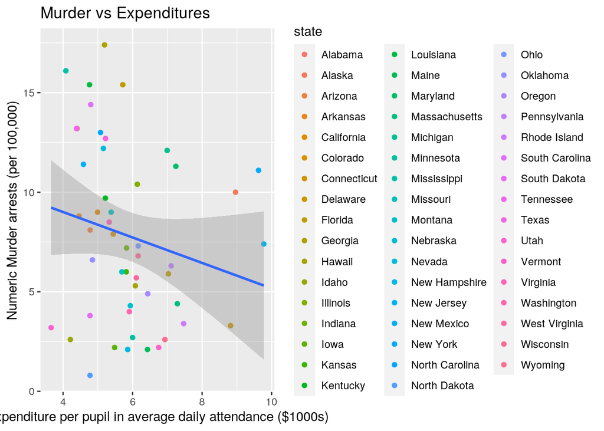

```r
ggplot(statesjoined, aes(expend, Murder)) + geom_point(aes(color = state)) +
    ggtitle("Murder vs Expenditures") + xlab("Expenditure per pupil in average daily attendance ($1000s)") +
    ylab("Numeric\tMurder arrests (per 100,000)") + geom_smooth(method = "lm")
```

There is a slight negative relationship between numeric murder arrests (per 100,000) and expenditure per pupil in average daily attendance. While I had anticipated a stronger correlation, it is sufficient to expect that state’s that spend more on students in average daily attendance could possibly lead to better education and therefore less murder arrests. However, there is a gap between the age of the students in school and those being arrested for murder, so expenditures could have shifted over the years. The purpose of the chart is to see the general trends per states to see if states that prioritize finances on educating their citizens more have less murder arrests.

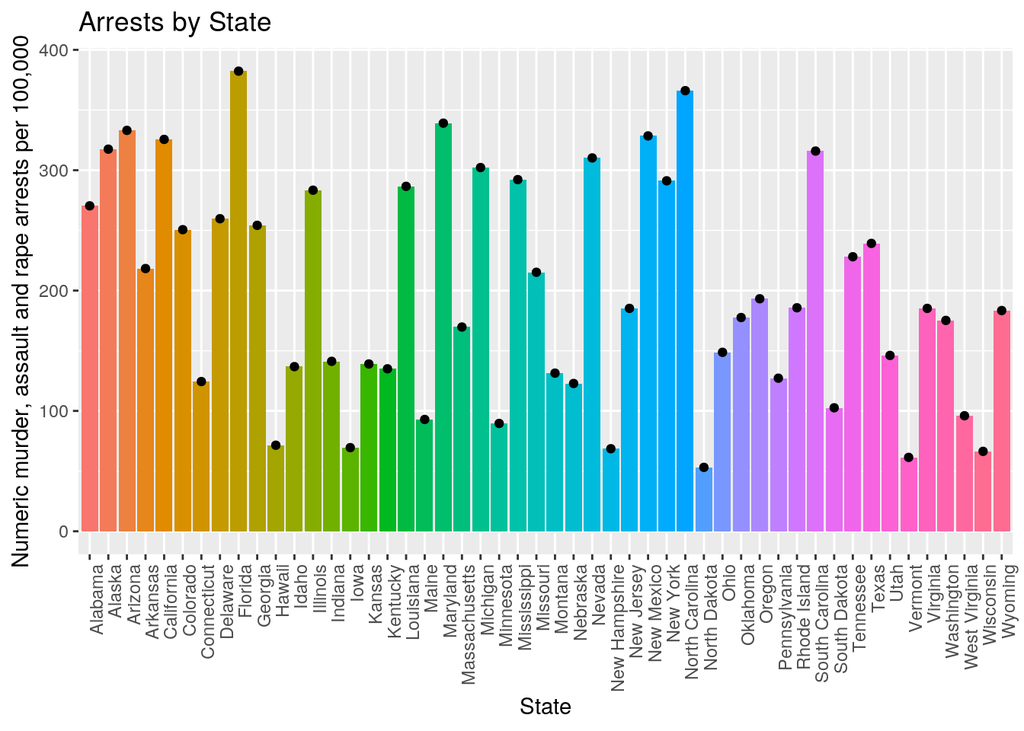

```r
ggplot(data = statesjoined, aes(x = state, y = totalcrimes, fill = state)) +
    geom_bar(stat = "identity") + geom_point() + theme(axis.text.x = element_text(angle = 90,
    hjust = 1)) + xlab("State") + ylab("Numeric\tmurder, assault and rape arrests per 100,000") +
    ggtitle("Arrests by State") + theme(legend.position = "none")
```

```r
statesjoined %>% group_by(state, expend) %>% arrange(expend)
```

```
## # A tibble: 50 x 14
## # Groups:   state, expend [50]
##        X state expend ratio salary  frac verbal  math   sat Murder Assault
##    <int> <chr>  <dbl> <dbl>  <dbl> <int>  <int> <int> <int>  <dbl>   <int>
##  1    44 Utah    3.66  24.3   29.1     4    513   563  1076    3.2     120
##  2    24 Miss…   4.08  17.5   26.8     4    496   540  1036   16.1     259
##  3    12 Idaho   4.21  19.1   29.8    15    468   511   979    2.6     120
##  4    42 Tenn…   4.39  18.6   32.5    12    497   543  1040   13.2     188
##  5     1 Alab…   4.40  17.2   31.1     8    491   538  1029   13.2     236
##  6     4 Arka…   4.46  17.1   28.9     6    482   523  1005    8.8     190
##  7    31 New …   4.59  17.2   28.5    11    485   530  1015   11.4     285
##  8    18 Loui…   4.76  16.8   26.5     9    486   535  1021   15.4     249
##  9    34 Nort…   4.78  15.3   26.3     5    515   592  1107    0.8      45
## 10    41 Sout…   4.78  14.4   26.0     5    505   563  1068    3.8      86
## # … with 40 more rows, and 3 more variables: UrbanPop <int>, Rape <dbl>,
## #   totalcrimes <dbl>
```

```r
statesjoined %>% group_by(state, expend) %>% arrange(salary)
```

```
## # A tibble: 50 x 14
## # Groups:   state, expend [50]
##        X state expend ratio salary  frac verbal  math   sat Murder Assault
##    <int> <chr>  <dbl> <dbl>  <dbl> <int>  <int> <int> <int>  <dbl>   <int>
##  1    41 Sout…   4.78  14.4   26.0     5    505   563  1068    3.8      86
##  2    34 Nort…   4.78  15.3   26.3     5    515   592  1107    0.8      45
##  3    18 Loui…   4.76  16.8   26.5     9    486   535  1021   15.4     249
##  4    24 Miss…   4.08  17.5   26.8     4    496   540  1036   16.1     259
##  5    36 Okla…   4.84  15.5   28.2     9    491   536  1027    6.6     151
##  6    31 New …   4.59  17.2   28.5    11    485   530  1015   11.4     285
##  7    26 Mont…   5.69  16.3   28.8    21    473   536  1009    6       109
##  8     4 Arka…   4.46  17.1   28.9     6    482   523  1005    8.8     190
##  9    44 Utah    3.66  24.3   29.1     4    513   563  1076    3.2     120
## 10    12 Idaho   4.21  19.1   29.8    15    468   511   979    2.6     120
## # … with 40 more rows, and 3 more variables: UrbanPop <int>, Rape <dbl>,
## #   totalcrimes <dbl>
```

```r
statesjoined %>% group_by(state, expend) %>% arrange(totalcrimes)
```

```
## # A tibble: 50 x 14
## # Groups:   state, expend [50]
##        X state expend ratio salary  frac verbal  math   sat Murder Assault
##    <int> <chr>  <dbl> <dbl>  <dbl> <int>  <int> <int> <int>  <dbl>   <int>
##  1    34 Nort…   4.78  15.3   26.3     5    515   592  1107    0.8      45
##  2    45 Verm…   6.75  13.8   35.4    68    429   472   901    2.2      48
##  3    49 Wisc…   6.93  15.9   37.7     9    501   572  1073    2.6      53
##  4    29 New …   5.86  15.6   34.7    70    444   491   935    2.1      57
##  5    15 Iowa    5.48  15.8   31.5     5    516   583  1099    2.2      56
##  6    11 Hawa…   6.08  17.9   38.5    57    407   482   889    5.3      46
##  7    23 Minn…   6     17.5   35.9     9    506   579  1085    2.7      72
##  8    19 Maine   6.43  13.8   32.0    68    427   469   896    2.1      83
##  9    48 West…   6.11  14.8   31.9    17    448   484   932    5.7      81
## 10    41 Sout…   4.78  14.4   26.0     5    505   563  1068    3.8      86
## # … with 40 more rows, and 3 more variables: UrbanPop <int>, Rape <dbl>,
## #   totalcrimes <dbl>
```

[figure not shown]

```r
ggplot(statesjoined, aes(x = state, y = sat, color = state)) +
    geom_boxplot() + theme(legend.position = "none") + ggtitle("SAT scores by State") +
    xlab("State") + ylab("Average Total SAT Score")
```

```r
statesjoined %>% group_by(state, expend) %>% arrange(sat)
```

```
## # A tibble: 50 x 14
## # Groups:   state, expend [50]
##        X state expend ratio salary  frac verbal  math   sat Murder Assault
##    <int> <chr>  <dbl> <dbl>  <dbl> <int>  <int> <int> <int>  <dbl>   <int>
##  1    40 Sout…   4.80  16.4   30.3    58    401   443   844   14.4     279
##  2    10 Geor…   5.19  16.3   32.3    65    406   448   854   17.4     211
##  3    33 Nort…   5.08  16.2   30.8    60    411   454   865   13       337
##  4    38 Penn…   7.11  17.1   44.5    70    419   461   880    6.3     106
##  5    14 Indi…   5.83  17.5   36.8    58    415   467   882    7.2     113
##  6    39 Rhod…   7.47  14.7   40.7    70    425   463   888    3.4     174
##  7     9 Flor…   5.72  19.1   32.6    48    420   469   889   15.4     335
##  8    11 Hawa…   6.08  17.9   38.5    57    407   482   889    5.3      46
##  9    32 New …   9.62  15.2   47.6    74    419   473   892   11.1     254
## 10    43 Texas   5.22  15.7   31.2    47    419   474   893   12.7     201
## # … with 40 more rows, and 3 more variables: UrbanPop <int>, Rape <dbl>,
## #   totalcrimes <dbl>
```

Overall, there was no significant indication that there is a large negative correlation between expenditures per pupil and murder arrests, or arrests in general. Further and more in depth study would have to occur. Furthermore, timelines of the data may contribute in the sense that while both data was collected was collected in the same time frame, those of the age of being arrested may have been significantly older than that of school-going age, and may have not attended school in that specific state. This study was just intended to see state trends overall regarding educational expenditures/prioritization versus crime arrests, as it would be expected that higher levels of education would result in less crime. * )